# Comparing lexicons using GNM

DBH, KT

2025-05-17

# Preparations

We load the necessary libraries and set the number of cores

```r
rm(list=ls())

# Install libraries if not installed already and load libraries
if(!require(checkmate)){install.packages("checkmate")}
if(!require(lingdist)){install.packages("lingdist")}
if(!require(parallel)){install.packages("parallel")}
if(!require(DT)){install.packages("DT")}
if(!require(Ckmeans.1d.dp)){install.packages("Ckmeans.1d.dp")}
if(!require(RColorBrewer)){install.packages("RColorBrewer")}
if(!require(ggplot2)){install.packages("ggplot2")}
if(!require(ggrepel)){install.packages("ggrepel")}
if(!require(factoextra)){install.packages("factoextra")}
if(!require(GGally)){install.packages("GGally")}
if(!require(viridis)){install.packages("viridis")}
if(!require(ragg)){install.packages("ragg")}
# The number of computing cores to use. The default is to use all available cores minus 2
reserved_cores = 2 # reserved some cores for background tasks
Cores = detectCores() - reserved_cores
```

# Step 1: Parameter setting

We define the parameters for our modeling. There are three general free parameters: the exponetial parameter (`D`), the cost for correct segment matches (`iden`), and the cost of insertion and deletion (`indel`).

```r
###################################
## Parameters: String similarity ##
###################################

## Cost for matched segments (min: 0, max: 1, default: 0)
iden = 0

## Cost for insertion or deletion of segments (min: 0, max: 1, default: 0.7)
indel = 0.7
## Albright (2007)'s simulation uses the value 0.7, which we will use as the default.
## Note that Albright's alignment tool uses 0.6 (reference: https://web.mit.edu/albright/www/software/Alignment.zip)
## "The default is set to .6, which seems to yield intuitive alignments in a large number of cases." in `ReadMe.txt`

## Feature underspecification (min: 0, max: 1, default: 0.25)
underspec_cost = 0.25
## To take into account of featural underspecification, if two feature values are the same, then the cost is 0, if different than 1. If one of the two feature values is underspecified, then it is not as bad as being different, so it has a lower cost than 1, but higher than 0.
## Default value: underspec_cost = 0.25, taken from PhonologicalCorpusTools (https://github.com/PhonologicalCorpusTools/CorpusTools/blob/master/corpustools/symbolsim/phono_align.py#L10)
## If underspec_cost = 1, then underspecification is ignored, so a mismatch between 0 and another value +/- would be the same as a mismatch between + with -.

################################
## Parameters: Distance decay ##
################################
## Distance decay parameter (D = 1/s, default: s = 0.1739). s = sensitivity, a parameter that controls the magnitude of the advantage that very similar neighbors have in determining the outcome
D = 1/0.1739
## We use the value from Albright (2007) for D. The author calls it 1/s, where s = 0.1739.

##################################
## Parameters: Frequency effect ##
##################################
## Frequency is weighted using a quadratic equation
## Bailey and Hahn's 2001 has a quadratic equation for modelling linear and non-linear effects of frequency. The optimal function in their study is one which gives medium frequency words the greatest contribution. By default, we assume a monotonic relationship, therefore `freq_quad_coeff` and `freq_content_coeff` are 0, and `freq_linear_coeff` is 1. Users should experiment with different values to identify a combination of values that fits their empirical data best.

# Whether to apply frequency weighting
frequency_weighting_tf = TRUE

## Quadratic coefficient to model a quadratic frequency effect
freq_quad_coeff = 0
## Linear coefficient to model a linear frequency effect
freq_linear_coeff = 1
## The constant coefficient
freq_content_coeff = 0

#####################################################
## Parameters: Preprocessing input frequency values #
#####################################################
## The frequency type of the reference lexicon
reference_frequency_type = 'RAW'
## Possible types: RAW (raw token frequency) and FPM (frequency per million)

## Frequency of choice: the frequency to use for GNM
frequency_normalised_tf = FALSE
## In Bailey and Hahn's 2001, raw token frequency was used for the log transformation.
## An alternative would be to use normalised frequency, e.g., frequency per million
## If frequency_normalised_tf is FALSE, then we'd use raw token frequency, otherwise we'd use normalised frequency
## If frequency_normalised_tf is TRUE and reference_frequency_type is 'RAW', then it would normalize your RAW frequency by assuming the sum of your token frequency count is the corpus size.
## If frequency_normalised_tf is TRUE and if the smallest value is less than 1, then we will rescale it to ensure that the smallest number is 1 or higher.
## If frequency_normalised_tf is FALSE and reference_frequency_type is 'FPM', then it would divide it by 1000000 and multiply it by X to get the smallest FPM to be 1. Then all numbers are rounded to the closest integer.

## Smoothing term for smoothing frequency values
SMOOTHVALUE = 1e-12
## Depending on `frequency_normalised_tf`, the frequency value to use for GNM will be whether RAW or FPM.
## If the smallest frequency value is not above 1, then `SMOOTHVALUE` is required because log10(1) would be zero, and that would mean that words with such a frequency value would NOT be contributing to the GNM -- an effect that we will like to avoid. Smoothing would increase all values by a small amount. Increasing the smooth value will give more weight to rarer events. By default, we use a small value (Lidstone smoothing) here.


## The function `checkParameters()` checks the input parameters for their variable type and possible values
checkParameters <- function(iden,indel,underspec_cost,D,
                            frequency_weighting_tf,
                            freq_quad_coeff,freq_linear_coeff,freq_content_coeff,
                            reference_frequency_type,frequency_normalised_tf,
                            SMOOTHVALUE
                            ){
  # Check parameters. It will throw an error message if any of them are FALSE
  assert(
    checkmate::checkNumber(iden),
    ((iden >= 0 & iden <= 1)),
    checkmate::checkNumber(indel),
    ((indel >= 0 & indel <= 1)),
    checkmate::checkNumber(underspec_cost),
    ((underspec_cost >= 0 & underspec_cost <= 1)),
    checkmate::checkNumber(D),
    checkmate::checkLogical(frequency_weighting_tf),
    checkmate::checkNumber(freq_quad_coeff),
    checkmate::checkNumber(freq_linear_coeff),
    checkmate::checkNumber(freq_content_coeff),
    checkmate::checkString(reference_frequency_type),
    checkmate::checkChoice(reference_frequency_type,c("RAW","FPM")),
    checkmate::checkLogical(frequency_normalised_tf),
    checkmate::checkNumber(SMOOTHVALUE),
    (SMOOTHVALUE >= 0),
    combine = "and"
  )
}
checkParameters(iden,indel,underspec_cost,D,
                frequency_weighting_tf,
                freq_quad_coeff,freq_linear_coeff,freq_content_coeff,
                reference_frequency_type,frequency_normalised_tf,
                SMOOTHVALUE)
```

# Step 2: Providing lexicons

With this code we load in the reference lexicon and the test lexicon as lists of words in IPA transcription.

```r
ref.lexicon = read.table('data/lexicon/ref_lex.csv', sep='\t',header=FALSE)
test.lexicon = read.table('data/lexicon/test_lex.csv', sep='\t',header=FALSE)
```

```r
## Reference lexicon
ref.lexicon$Outcomes = ref.lexicon$V1
ref.lexicon$Frequency = 1
ref.lexicon$IPA = ref.lexicon$V1
ref.lexicon$V1 = NULL

## Test lexicon
test.lexicon$Outcomes = test.lexicon$V1
test.lexicon$Frequency = 1
test.lexicon$IPA = test.lexicon$V1
test.lexicon$V1 = NULL
```

# Step 3: Providing phonological features

To translate IPA symbols into phonological features we read in a universal feature table. It contains phonological feature specifications for IPA symbols.

```r
feature.table.df = read.table('data/featureChart/phoible-segments-features.tsv',
   sep='\t',header=TRUE)
```

The feature table needs to be trimmed such that the table is reduced to only those IPA symbols which are relevant in the reference lexicon. Therefore both reference an test items and put together into one vector. IPA entries are checked against the feature table. Missing features are identified.

```r
all.lexicon = rbind(ref.lexicon, test.lexicon)

## Check if all symbols are covered in the feature.table
## This function extracts all unique IPA segments from a vector of IPA strings.
grabSegmentTypes =  function(IPA_strings){
  # Check parameters
  checkmate::assert_character(IPA_strings)

  w=strsplit(IPA_strings,' ')
  w= unlist(w)
  seg.types = unique(w)
  return(seg.types)
}

## This function checks if all vector of IPA strings are found in feature table. It returns the missing segments.
checkIPAinFeatTable =  function(IPA_strings,feature.table.df){
  ## Check parameters
  checkmate::assert_character(IPA_strings)
  checkmate::assert_data_frame(feature.table.df)

  seg.types = grabSegmentTypes(IPA_strings)
  missing_IPAs = seg.types[!(seg.types %in% feature.table.df$segment)]
  return(missing_IPAs)
}

Missing_IPAs = checkIPAinFeatTable(all.lexicon$IPA,feature.table.df)
if (length(Missing_IPAs) == 0) {
  print ("No missing IPA symbols")
} else {
  print (paste0('Missing ', length(Missing_IPAs), " IPA symbols: ", paste0(Missing_IPAs, collapse = ' ')))
  print ('Please add these missing IPA symbols and their feature values to `feature.table.df` either in the text file itself or add in R after you have loaded the table')
  knitr::knit_exit()
}
```

[output not shown]

Redundant features are identified and deleted.

```r
## These lines reduces the feature table to only the segments that we need, identifying unique IPA symbols used in the current data set
seg.types = grabSegmentTypes(all.lexicon$IPA)
feature.table.df = subset(feature.table.df,segment%in%seg.types)

## These lines reduces the features that are not needed, i.e. the features with the same value across all segments.
redund_cols = c()
for (col in names(feature.table.df)) {
  if (dim(unique(feature.table.df[col]))[1] == 1){
    redund_cols = append(redund_cols,col)
  }
}

print(paste0(length(redund_cols), ' redundent features were found: ', paste0(redund_cols, collapse = ', ')))
## Check dimensions before trimming
dimensions_before_trimming = dim(feature.table.df)
## Trimming
feature.table.df = feature.table.df[ , -which(names(feature.table.df) %in% redund_cols)]
## Check dimensions after trimming
dimensions_after_trimming = dim(feature.table.df)

paste0('Before feature trimming: ', dimensions_before_trimming[1], ' segments and ', dimensions_before_trimming[2], ' features')
paste0('After feature trimming: ', dimensions_after_trimming[1], ' segments and ', dimensions_after_trimming[2], ' features')
```

[output not shown]

# Step 4: Building a cost matrix for string similarity

In the first step, we define a function `phonDistMetric_FeatureMismatchWithUnderspec` to compute the distance between two phones based on their featural similarity. In the second step, we define a function `costdict_generate` that uses `phonDistMetric_FeatureMismatchWithUnderspec` to generate a cost matrix for all the phones being used in `feature.table.df` plus insertion and deletion segments. The cost matrix contains the distance values of the pairwise combinations of all phones, insertion and deletion.

```r
## Our phonetic distance metric differs from the one used by the GNM model reported in Bailey and Hahn (2001). In the original model, distance was computed using a metric based on shared natural classes (Frisch, 1996), while our metric is a normalised number of feature mismatches. In a separate study by Bailey and Hahn (2005), they evaluated how well can a) feature mismatching, b) Frisch’s metric, and c) empirical phoneme confusability in a number of word similarity judgement tasks, and they found that feature mismatching performed better than Frisch’s metric. Given the findings of Bailey and Hahn (2005), we decided to employ a feature mismatching metric over Frisch’s metric for our study.

## To take into account of featural underspecification, if two feature values are the same, then the cost is 0, if different than 1. If one of the two feature values is underspecified, then it is not as bad as being different, so it has a lower cost than 1, but higher than 0.
# Default value: underspec_cost = 0.25, taken from PhonologicalCorpusTools (https://github.com/PhonologicalCorpusTools/CorpusTools/blob/master/corpustools/symbolsim/phono_align.py#L10)
## If underspec_cost = 1, then underspecification is ignored, so a mismatch between 0 and another value +/- would be the same as a mismatch between + with -.
phonDistMetric_FeatureMismatchWithUnderspec <- function(s1,s2, feature.table.df, underspec_cost = 0.25) {
  # Check parameters
  checkmate::assert_string(s1)
  checkmate::assert_string(s2)
  checkmate::assert_data_frame(feature.table.df)
  checkmate::assert_number(underspec_cost)

  s1_fs = subset(feature.table.df,segment == s1)
  s1_fs$segment = NULL
  s1_fs = as.character(s1_fs)

  s2_fs = subset(feature.table.df,segment == s2)
  s2_fs$segment = NULL
  s2_fs = as.character(s2_fs)

  check_feature_difference <- function(val1, val2, underspec_cost) {
    if (val1 == val2) {
      return (0)
    } else if (val1 == '0' | val2 == '0') {
      return (underspec_cost)
    } else {
      return (1)
    }
  }

  cost_results <- numeric(length(s1_fs))
  for (i in 1:length(s1_fs)) {
  cost_results[i] <- check_feature_difference(s1_fs[i], s2_fs[i], underspec_cost)
  }

  NS = sum(cost_results)
  S_plus_NS = length(cost_results)
  d = (NS)/(S_plus_NS)
  return (d)
}

costdict_generate <- function(feature.table.df, iden, indel, underspec_cost) {
  ## Check parameters
  checkmate::assert_data_frame(feature.table.df)
  checkmate::assert_number(iden)
  checkmate::assert_number(indel)
  checkmate::assert_number(underspec_cost)

  seglist = feature.table.df$segment
  seglist = append(seglist,"_NULL_")
  seg1_vec = c()
  seg2_vec = c()
  seg12_dist_vec = c()
  for (seg1 in seglist) {
      for (seg2 in seglist) {
        seg1_vec = append(seg1_vec,seg1)
        seg2_vec = append(seg2_vec,seg2)
        if (seg1 == seg2) {
            dist_value = iden
        } else {
            if ( (seg1 == '_NULL_' & seg2 != '_NULL_' ) | (seg1 != '_NULL_' & seg2 == '_NULL_')) { # indel
              dist_value = indel
            } else {
              dist_value = phonDistMetric_FeatureMismatchWithUnderspec(seg1,seg2,feature.table.df,underspec_cost)
            }
        }
        seg12_dist_vec = append(seg12_dist_vec,dist_value)
      }
  }

  ## Dataframe in long table form. The first and second columns are labels and the
  ## third column stores the distance values
  cost_dataframe = data.frame(seg1 = seg1_vec, seg2 = seg2_vec, dist = seg12_dist_vec)

  ## Use `long2squareform` to convert this to a matrix.
  cost_matrix = long2squareform(cost_dataframe, symmetric = FALSE)
  return (cost_matrix)
}

cost_matrix = costdict_generate(feature.table.df, iden, indel, underspec_cost)

print(cost_matrix)
```

```
##        _NULL_          a          b          d          e         eː          i
## _NULL_    0.0 0.70000000 0.70000000 0.70000000 0.70000000 0.70000000 0.70000000
## a         0.7 0.00000000 0.34821429 0.35714286 0.08035714 0.11607143 0.11607143
## b         0.7 0.34821429 0.00000000 0.11607143 0.35714286 0.39285714 0.35714286
## d         0.7 0.35714286 0.11607143 0.00000000 0.36607143 0.40178571 0.36607143
## e         0.7 0.08035714 0.35714286 0.36607143 0.00000000 0.03571429 0.03571429
## eː        0.7 0.11607143 0.39285714 0.40178571 0.03571429 0.00000000 0.07142857
## i         0.7 0.11607143 0.35714286 0.36607143 0.03571429 0.07142857 0.00000000
## iː        0.7 0.15178571 0.39285714 0.40178571 0.07142857 0.03571429 0.03571429
## kʰ        0.7 0.36607143 0.19642857 0.20535714 0.37500000 0.41071429 0.33928571
## l         0.7 0.27678571 0.26785714 0.15178571 0.28571429 0.32142857 0.28571429
## m         0.7 0.33928571 0.08035714 0.19642857 0.34821429 0.38392857 0.34821429
## n         0.7 0.34821429 0.19642857 0.08035714 0.35714286 0.39285714 0.35714286
## o         0.7 0.13392857 0.33928571 0.41964286 0.12500000 0.16071429 0.16071429
## oː        0.7 0.16964286 0.37500000 0.45535714 0.16071429 0.12500000 0.19642857
## tʰ        0.7 0.42857143 0.18750000 0.07142857 0.43750000 0.47321429 0.43750000
## u         0.7 0.16964286 0.33928571 0.41964286 0.16071429 0.19642857 0.12500000
## uː        0.7 0.20535714 0.37500000 0.45535714 0.19642857 0.16071429 0.16071429
## ɑː        0.7 0.07142857 0.38392857 0.39285714 0.15178571 0.11607143 0.18750000
## ɡ         0.7 0.29464286 0.12500000 0.13392857 0.30357143 0.33928571 0.26785714
##                iː         kʰ         l          m          n          o
## _NULL_ 0.70000000 0.70000000 0.7000000 0.70000000 0.70000000 0.70000000
## a      0.15178571 0.36607143 0.2767857 0.33928571 0.34821429 0.13392857
## b      0.39285714 0.19642857 0.2678571 0.08035714 0.19642857 0.33928571
## d      0.40178571 0.20535714 0.1517857 0.19642857 0.08035714 0.41964286
## e      0.07142857 0.37500000 0.2857143 0.34821429 0.35714286 0.12500000
## eː     0.03571429 0.41071429 0.3214286 0.38392857 0.39285714 0.16071429
## i      0.03571429 0.33928571 0.2857143 0.34821429 0.35714286 0.16071429
## iː     0.00000000 0.37500000 0.3214286 0.38392857 0.39285714 0.19642857
## kʰ     0.37500000 0.00000000 0.3571429 0.27678571 0.28571429 0.42857143
## l      0.32142857 0.35714286 0.0000000 0.25892857 0.14285714 0.33928571
## m      0.38392857 0.27678571 0.2589286 0.00000000 0.11607143 0.33035714
## n      0.39285714 0.28571429 0.1428571 0.11607143 0.00000000 0.41071429
## o      0.19642857 0.42857143 0.3392857 0.33035714 0.41071429 0.00000000
## oː     0.16071429 0.46428571 0.3750000 0.36607143 0.44642857 0.03571429
## tʰ     0.47321429 0.13392857 0.2232143 0.26785714 0.15178571 0.49107143
## u      0.16071429 0.39285714 0.3392857 0.33035714 0.41071429 0.03571429
## uː     0.12500000 0.42857143 0.3750000 0.36607143 0.44642857 0.07142857
## ɑː     0.15178571 0.43750000 0.3125000 0.37500000 0.38392857 0.13392857
## ɡ      0.30357143 0.07142857 0.2857143 0.20535714 0.21428571 0.35714286
##                oː         tʰ          u         uː         ɑː          ɡ
## _NULL_ 0.70000000 0.70000000 0.70000000 0.70000000 0.70000000 0.70000000
## a      0.16964286 0.42857143 0.16964286 0.20535714 0.07142857 0.29464286
## b      0.37500000 0.18750000 0.33928571 0.37500000 0.38392857 0.12500000
## d      0.45535714 0.07142857 0.41964286 0.45535714 0.39285714 0.13392857
## e      0.16071429 0.43750000 0.16071429 0.19642857 0.15178571 0.30357143
## eː     0.12500000 0.47321429 0.19642857 0.16071429 0.11607143 0.33928571
## i      0.19642857 0.43750000 0.12500000 0.16071429 0.18750000 0.26785714
## iː     0.16071429 0.47321429 0.16071429 0.12500000 0.15178571 0.30357143
## kʰ     0.46428571 0.13392857 0.39285714 0.42857143 0.43750000 0.07142857
## l      0.37500000 0.22321429 0.33928571 0.37500000 0.31250000 0.28571429
## m      0.36607143 0.26785714 0.33035714 0.36607143 0.37500000 0.20535714
## n      0.44642857 0.15178571 0.41071429 0.44642857 0.38392857 0.21428571
## o      0.03571429 0.49107143 0.03571429 0.07142857 0.13392857 0.35714286
## oː     0.00000000 0.52678571 0.07142857 0.03571429 0.09821429 0.39285714
## tʰ     0.52678571 0.00000000 0.49107143 0.52678571 0.46428571 0.20535714
## u      0.07142857 0.49107143 0.00000000 0.03571429 0.16964286 0.32142857
## uː     0.03571429 0.52678571 0.03571429 0.00000000 0.13392857 0.35714286
## ɑː     0.09821429 0.46428571 0.16964286 0.13392857 0.00000000 0.36607143
## ɡ      0.39285714 0.20535714 0.32142857 0.35714286 0.36607143 0.00000000
```

```r
# dum_output = edit_dist_string("k a s", "k a l t", delim = " ", cost_matrix, return_alignments = TRUE)
# dum_output$alignments
```

# Step 5: Preprocessing: reference lexicon frequency

```r
## Generate Frequency_RAW or Frequency_FPM column in the ref.lexicon
if ( (reference_frequency_type == "RAW")) {
  ref.lexicon$Frequency_RAW = ref.lexicon$Frequency
} else if ( (reference_frequency_type == "FPM")) {
  ref.lexicon$Frequency_FPM = ref.lexicon$Frequency
}

## If frequency_normalised_tf is TRUE and reference_frequency_type is 'RAW', then it would normalize your RAW frequency by assuming the sum of your token frequency count is the corpus size.
if ( (reference_frequency_type == "RAW") & (frequency_normalised_tf == TRUE) ) {
  ApproxCorpusSize = sum(ref.lexicon$Frequency_RAW)
  ref.lexicon$Frequency_FPM =ApproxCorpusSize*1000000
  print (paste0('We have converted your raw token frequency into frequency per million by assuming your corpus size to be ', as.character(ApproxCorpusSize), ' words'))
}

## If frequency_normalised_tf is FALSE and reference_frequency_type is 'FPM', then it would divide it by 1000000 and multiply it by ApproxCorpusSize to get the smallest FPM to be 1.
if ( (reference_frequency_type == "FPM") & (frequency_normalised_tf == FALSE) ) {
  ref.lexicon$Frequency_RAW = ref.lexicon$Frequency_FPM/1000000
  ApproxCorpusSize <- 1 / min(ref.lexicon$Frequency_RAW)
  ref.lexicon$Frequency_RAW = round(ref.lexicon$Frequency_RAW * ApproxCorpusSize)
  print (paste0('We have converted your frequency per million into token frequency by approximating a corpus size of ', as.character(ApproxCorpusSize), ' words'))
}

## If the smallest Frequency per million is less than 1, there will be a problem after log10 transformation.
# because the resultant values will be negative. These items with a negative log10 frequency will then be contributing negatively which is not possible. The solution is to multiply it by 10 to the power of N where N is dependent on how much scaling we'd need to make the smallest FPM > 1.
if (frequency_normalised_tf == TRUE) {
  # the smallest value
  min_Frequency_FPM = min(ref.lexicon$Frequency_FPM)
  if (min_Frequency_FPM < 1) {
    N <- ceiling(log10(1/min_Frequency_FPM))
    ref.lexicon$Frequency_FPM = ref.lexicon$Frequency_FPM*(10^N)
    print (paste0('We have rescaled your frequency per million by multiplying it by ', as.character(10^N)))
  }
}

## If the smallest frequency value (RAW or FPM) is 1, we need to smooth it to be above 1. It's because log10(1) would be zero and it would mean that that word would not contribute to the GNM. See Bailey and Hahn (2001, p.573) for how they added 2 to their token frequency to include those with a frequency value of 0.
## We will apply lidstone smoothing
if ( (reference_frequency_type == "RAW")) {
  if (min(ref.lexicon$Frequency_RAW) == 1) {
    ref.lexicon$Frequency_RAW = ref.lexicon$Frequency_RAW + SMOOTHVALUE
    print (paste0('We have smoothed your raw token frequency by adding ', as.character(SMOOTHVALUE)))
  }
} else if ( (reference_frequency_type == "FPM")) {
  if (min(ref.lexicon$Frequency_FPM) == 1) {
    ref.lexicon$Frequency_FPM = ref.lexicon$Frequency_FPM + SMOOTHVALUE
    print (paste0('We have smoothed your frequency per million by adding ', as.character(SMOOTHVALUE)))
  }
}
```

```
## [1] "We have smoothed your raw token frequency by adding 1e-12"
```

# Step 6: Estimate GNM values for test items

```r
## Select the type of frequency based on user's input
if (frequency_normalised_tf == TRUE) {
  ref_lexicon_log10frequency_vec = log10(ref.lexicon$Frequency_FPM)
} else {
  ref_lexicon_log10frequency_vec = log10(ref.lexicon$Frequency_RAW)
}

## Generate the frequency term
frequency_term = freq_quad_coeff * ref_lexicon_log10frequency_vec^2 + freq_linear_coeff * ref_lexicon_log10frequency_vec + freq_content_coeff

## Compute the GNM scores
GNM_results <- numeric(length(test.lexicon$IPA))
num_reflexicon = length(ref.lexicon$IPA)
pb = txtProgressBar(min = 0, max = length(GNM_results), initial = 0,style = 3)
for (i in 1:length(GNM_results)) {
  setTxtProgressBar(pb,i)
  test_word = test.lexicon$IPA[i]

  ## Generate the psychological distance between the test item and all the words in the reference lexicon. Result: a vector of distances
  pairwise_dist_result <- mclapply(1:num_reflexicon, function(i) {
                          edit_dist_string(ref.lexicon$IPA[i], test_word, delim = " ", cost_matrix)$distance
                          }, mc.cores = Cores)
  pairwise_dist_result = unlist(pairwise_dist_result)

  ## Multiply the distances with the decay parameter and apply the exponential function (e ≈ 2.71828)
  exp_vec = exp(-D*pairwise_dist_result)

  ## Frequency weighting: the Element wise multiplication of the exp_vec with the frequency term
  if (frequency_weighting_tf) {
    freq_weighted_dist_vec = exp_vec * frequency_term
  } else {
    freq_weighted_dist_vec = exp_vec
  }
  ## Sum the values to get the GNM score
  GNM_results[i] = sum(freq_weighted_dist_vec)
}
close(pb)
```

# Step 7: Output file with estimated lexical similarity

```r
test.lexicon$Frequency = NULL
test.lexicon$Cues = NULL

test.list.with.wordlikeness = test.lexicon
test.list.with.wordlikeness$GNM = GNM_results

## Using the DT library, we can allow users to search with a data table.
datatable(test.list.with.wordlikeness,options = list(autoWidth = TRUE), filter = list(
  position = 'top', clear = FALSE))
```

|  | Outcomes | IPA | GNM |
| --- | --- | --- | --- |
| 1 | b ɑː n u | b ɑː n u | 5.19694929835976e-13 |
| 2 | b eː d a | b eː d a | 6.388822135304143e-13 |
| 3 | b iː d u | b iː d u | 6.240597853266948e-13 |
| 4 | b iː kʰ o | b iː kʰ o | 4.812922352510947e-13 |
| 5 | b oː kʰ i | b oː kʰ i | 6.499237115839522e-13 |
| 6 | d iː kʰ u | d iː kʰ u | 6.007608469454497e-13 |
| 7 | d ɑː n o | d ɑː n o | 6.397930331111187e-13 |
| 8 | d eː n i | d eː n i | 6.48005756157125e-13 |
| 9 | d iː b a | d iː b a | 6.211239123251404e-13 |
| 10 | ɡ ɑː l u | ɡ ɑː l u | 8.552099728984458e-13 |

[output cut: 3 more lines]

```r
## Write as a tsv (tab delimited file)
write.table(test.list.with.wordlikeness, file ="data/output/items.with.GNMwordlikelihood.tsv",sep='\t')
```

# Visualisation

This visualisation can be useful for identifying test item that are outliers (particularly wordlike or nonwordlike).

## Visualisation: optimal (weighted) univariate clustering

The following code visualizes GNM results using optimal (weighted) univariate clustering.

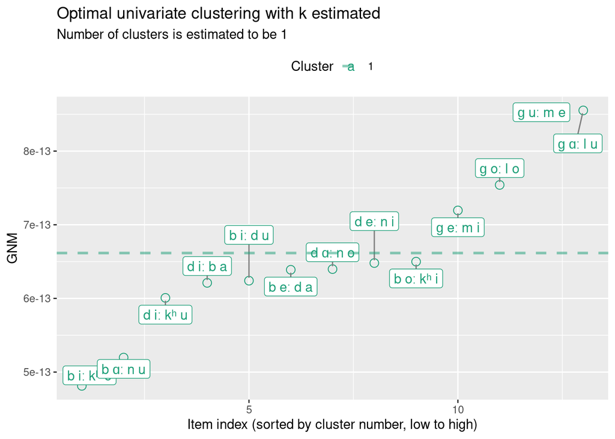

```r
# Users can select one variable from the following
# "GNM"
word.likeliness.variables = c("GNM")
for (word.likeliness.variable in word.likeliness.variables) {

    test.list.df <- test.list.with.wordlikeness[,c("Outcomes",word.likeliness.variable)]

    # Source: https://cran.r-project.org/web/packages/Ckmeans.1d.dp/vignettes/Ckmeans.1d.dp.html
    result <- Ckmeans.1d.dp(test.list.df[,word.likeliness.variable])
    k <- max(result$cluster)
    colors <- brewer.pal(k, "Dark2")

    # Add cluster into to dataframe
    cluster_center.df = data.frame(cluster = c(1:length(result$centers)), centers = result$centers)
    test.list.df$cluster = result$cluster
    test.list.df = merge(test.list.df,cluster_center.df, by.x= "cluster", by.y= "cluster")
    test.list.df = test.list.df[
      with(test.list.df, order(test.list.df$cluster, test.list.df[,word.likeliness.variable])),
    ]
    test.list.df = test.list.df[,c('Outcomes',word.likeliness.variable,"cluster",'centers')]

    # Create a ggplot object
    p <- ggplot(test.list.df, aes(x = c(1:dim(test.list.df)[1]),
                                  y = test.list.df[,2],
                                  color = factor(cluster), shape = factor(cluster), label = Outcomes)) +
      geom_point(size = 3) +
      geom_label_repel(aes(label = Outcomes),
                      box.padding   = 0.35,
                      point.padding = 0.5,
                      min.segment.length = 0,
                      force_pull = 0.5,
                      max.overlaps = 100,
                      direction = 'y',
                      segment.color = 'grey50',max.time=10)+
      # Add dashed lines for cluster centers
      geom_hline(data = test.list.df, aes(yintercept = centers,color = factor(cluster)), linetype = "dashed",  linewidth = 1, alpha = 0.5) +


      # Add titles and labels
      labs(title = "Optimal univariate clustering with k estimated",
           subtitle = paste("Number of clusters is estimated to be", k),
           x = "Item index (sorted by cluster number, low to high)",y=word.likeliness.variable) +
      # Add legend
      scale_color_manual(values = colors[1:k], name = "Cluster") +
      scale_shape_manual(values = 1:k, name = "Cluster") +
      theme(legend.position = "top")

    # Print the ggplot object
    print(p)
}
```

# Session Info

```r
print(sI, RNG = FALSE, locale = FALSE)
```

[output not shown]